# Final Project

Sai Anjesh

2024-04-16

# HOTEL RESERVATION CANCELLATION PREDCITION

```r
## Importing Necessary Libraries
##---------
FUNCTIONS_PATH = "D:/UIS/Studies/Semester4/CSC532/Assignments/ML_Final_Project/ml_final_project/code_base/custom_functions.R"
##---------
source(FUNCTIONS_PATH)
##---------
library(dplyr)
library(ROCR)
library(caret)
library(glmnet)
library(randomForest)
library(gbm)
library(keras)
library(tfruns)
library(abind)
library(mltools)
library(data.table)
library(pROC)
##---------
```

```r
# I am creating this to save models
# Most of the models take time to run
# Can uuse these model objects later during the process

# CHAT_GPT Assistance: how to create folder if it does not exist in R?
# Specify the path to the folder you want to create
models_folder_path <- "D:/UIS/Studies/Semester4/CSC532/Assignments/ML_Final_Project/ml_final_project/ALL_MODELS"
over_write_models <- T
# over_write_models <- F

# Check if the folder exists
if (!file.exists(models_folder_path)) {
  # If the folder does not exist, create it
  dir.create(models_folder_path)
  cat("Folder created successfully!\n")
} else {
  cat("Folder already exists!\n")
}
```

```
Folder already exists!
```

#### Let us import dataset

```r
## File Paths
input_folder_path = "D:/UIS/Studies/Semester4/CSC532/Assignments/ML_Final_Project/ml_final_project/input_datasets/"
input_file_name = "hotel_reservations_dataset/Hotel Reservations.csv"
hotel_reservation_data = paste(input_folder_path, input_file_name, sep = "")
```

```r
hotel_reservation_data <- read.csv(file = hotel_reservation_data, header = TRUE)
```

#### Let us check some basic information

```r
## Primitive Information
# Let us check the shape of the data
print(paste("Number of Records : ", dim(hotel_reservation_data)[1]))
```

```
[1] "Number of Records :  36275"
```

```r
print(paste("Number of Features : ", dim(hotel_reservation_data)[2]))
```

```
[1] "Number of Features :  19"
```

```r
# Let us check the feature name snad the structure
str(hotel_reservation_data)
```

```
'data.frame':   36275 obs. of  19 variables:
 $ Booking_ID                          : chr  "INN00001" "INN00002" "INN00003" "INN00004" ...
 $ no_of_adults                        : int  2 2 1 2 2 2 2 2 3 2 ...
 $ no_of_children                      : int  0 0 0 0 0 0 0 0 0 0 ...
 $ no_of_weekend_nights                : int  1 2 2 0 1 0 1 1 0 0 ...
 $ no_of_week_nights                   : int  2 3 1 2 1 2 3 3 4 5 ...
 $ type_of_meal_plan                   : chr  "Meal Plan 1" "Not Selected" "Meal Plan 1" "Meal Plan 1" ...
 $ required_car_parking_space          : int  0 0 0 0 0 0 0 0 0 0 ...
 $ room_type_reserved                  : chr  "Room_Type 1" "Room_Type 1" "Room_Type 1" "Room_Type 1" ...
 $ lead_time                           : int  224 5 1 211 48 346 34 83 121 44 ...
 $ arrival_year                        : int  2017 2018 2018 2018 2018 2018 2017 2018 2018 2018 ...
 $ arrival_month                       : int  10 11 2 5 4 9 10 12 7 10 ...
 $ arrival_date                        : int  2 6 28 20 11 13 15 26 6 18 ...
 $ market_segment_type                 : chr  "Offline" "Online" "Online" "Online" ...
 $ repeated_guest                      : int  0 0 0 0 0 0 0 0 0 0 ...
 $ no_of_previous_cancellations        : int  0 0 0 0 0 0 0 0 0 0 ...
 $ no_of_previous_bookings_not_canceled: int  0 0 0 0 0 0 0 0 0 0 ...
 $ avg_price_per_room                  : num  65 106.7 60 100 94.5 ...
 $ no_of_special_requests              : int  0 1 0 0 0 1 1 1 1 3 ...
 $ booking_status                      : chr  "Not_Canceled" "Not_Canceled" "Canceled" "Canceled" ...
```

```r
# Check the summary
summary(hotel_reservation_data)
```

```
  Booking_ID         no_of_adults   no_of_children    no_of_weekend_nights no_of_week_nights type_of_meal_plan
 Length:36275       Min.   :0.000   Min.   : 0.0000   Min.   :0.0000       Min.   : 0.000    Length:36275
 Class :character   1st Qu.:2.000   1st Qu.: 0.0000   1st Qu.:0.0000       1st Qu.: 1.000    Class :character
 Mode  :character   Median :2.000   Median : 0.0000   Median :1.0000       Median : 2.000    Mode  :character
                    Mean   :1.845   Mean   : 0.1053   Mean   :0.8107       Mean   : 2.204
                    3rd Qu.:2.000   3rd Qu.: 0.0000   3rd Qu.:2.0000       3rd Qu.: 3.000
                    Max.   :4.000   Max.   :10.0000   Max.   :7.0000       Max.   :17.000
 required_car_parking_space room_type_reserved   lead_time       arrival_year  arrival_month     arrival_date
 Min.   :0.00000            Length:36275       Min.   :  0.00   Min.   :2017   Min.   : 1.000   Min.   : 1.0
 1st Qu.:0.00000            Class :character   1st Qu.: 17.00   1st Qu.:2018   1st Qu.: 5.000   1st Qu.: 8.0
 Median :0.00000            Mode  :character   Median : 57.00   Median :2018   Median : 8.000   Median :16.0
 Mean   :0.03099                               Mean   : 85.23   Mean   :2018   Mean   : 7.424   Mean   :15.6
 3rd Qu.:0.00000                               3rd Qu.:126.00   3rd Qu.:2018   3rd Qu.:10.000   3rd Qu.:23.0
 Max.   :1.00000                               Max.   :443.00   Max.   :2018   Max.   :12.000   Max.   :31.0
 market_segment_type repeated_guest    no_of_previous_cancellations no_of_previous_bookings_not_canceled
 Length:36275        Min.   :0.00000   Min.   : 0.00000             Min.   : 0.0000
 Class :character    1st Qu.:0.00000   1st Qu.: 0.00000             1st Qu.: 0.0000
 Mode  :character    Median :0.00000   Median : 0.00000             Median : 0.0000
                     Mean   :0.02564   Mean   : 0.02335             Mean   : 0.1534
                     3rd Qu.:0.00000   3rd Qu.: 0.00000             3rd Qu.: 0.0000
                     Max.   :1.00000   Max.   :13.00000             Max.   :58.0000
 avg_price_per_room no_of_special_requests booking_status
 Min.   :  0.00     Min.   :0.0000         Length:36275
 1st Qu.: 80.30     1st Qu.:0.0000         Class :character
 Median : 99.45     Median :0.0000         Mode  :character
 Mean   :103.42     Mean   :0.6197
 3rd Qu.:120.00     3rd Qu.:1.0000
 Max.   :540.00     Max.   :5.0000
```

```r
print(summary(hotel_reservation_data_EDA$Date))
```

```
        Min.      1st Qu.       Median         Mean      3rd Qu.         Max.         NA's
"2017-07-01" "2018-02-28" "2018-06-12" "2018-05-24" "2018-09-19" "2018-12-31"         "37"
```

What we can understand here is there are just data poitns for 1.5 (From July 2017 to Dec 2018) years and very funny we have 29th feb date in year 2018. Yeah, I know right!? How can Feb have 29 days in 2018. Fun fact: Prices have been alloted for these dates.

This is either data entry problem or data loss / corruption problem.

```r
# Let us check date before and post 29 Feb 2018
dates_orig_data_grp <- (dates_orig_data %>%
                          group_by(Date) %>%
                          summarise(total = n()) %>%
                          filter(Date == as.Date("2018-02-28") | Date == as.Date("2018-03-01")))
```

```r
sum(is.na(date_check_data))
```

```
[1] 0
```

##### Let us check the NA values

```r
# Let us check the NA cases
# Check if there are missing values
# And let us do a thorough check
sum(is.na(hotel_reservation_data))
```

```
[1] 0
```

```r
colSums(is.na(hotel_reservation_data))
```

```
                          Booking_ID                         no_of_adults                       no_of_children
                                   0                                    0                                    0
                no_of_weekend_nights                    no_of_week_nights                    type_of_meal_plan
                                   0                                    0                                    0
          required_car_parking_space                   room_type_reserved                            lead_time
                                   0                                    0                                    0
                        arrival_year                        arrival_month                         arrival_date
                                   0                                    0                                    0
                 market_segment_type                       repeated_guest         no_of_previous_cancellations
                                   0                                    0                                    0
no_of_previous_bookings_not_canceled                   avg_price_per_room               no_of_special_requests
                                   0                                    0                                    0
                      booking_status
                                   0
```

```r
# Check 1
na_records <- hotel_reservation_data[!complete.cases(hotel_reservation_data), ]
```

Fortunately we don’t have NA values, we shall continue to transform the structure.

#### Let us convert the struture of the dataframe

```r
# Check the str
str(hotel_reservation_data)
```

```
'data.frame':   36275 obs. of  19 variables:
 $ Booking_ID                          : chr  "INN00001" "INN00002" "INN00003" "INN00004" ...
 $ no_of_adults                        : int  2 2 1 2 2 2 2 2 3 2 ...
 $ no_of_children                      : int  0 0 0 0 0 0 0 0 0 0 ...
 $ no_of_weekend_nights                : int  1 2 2 0 1 0 1 1 0 0 ...
 $ no_of_week_nights                   : int  2 3 1 2 1 2 3 3 4 5 ...
 $ type_of_meal_plan                   : chr  "Meal Plan 1" "Not Selected" "Meal Plan 1" "Meal Plan 1" ...
 $ required_car_parking_space          : int  0 0 0 0 0 0 0 0 0 0 ...
 $ room_type_reserved                  : chr  "Room_Type 1" "Room_Type 1" "Room_Type 1" "Room_Type 1" ...
 $ lead_time                           : int  224 5 1 211 48 346 34 83 121 44 ...
 $ arrival_year                        : int  2017 2018 2018 2018 2018 2018 2017 2018 2018 2018 ...
 $ arrival_month                       : int  10 11 2 5 4 9 10 12 7 10 ...
 $ arrival_date                        : int  2 6 28 20 11 13 15 26 6 18 ...
 $ market_segment_type                 : chr  "Offline" "Online" "Online" "Online" ...
 $ repeated_guest                      : int  0 0 0 0 0 0 0 0 0 0 ...
 $ no_of_previous_cancellations        : int  0 0 0 0 0 0 0 0 0 0 ...
 $ no_of_previous_bookings_not_canceled: int  0 0 0 0 0 0 0 0 0 0 ...
 $ avg_price_per_room                  : num  65 106.7 60 100 94.5 ...
 $ no_of_special_requests              : int  0 1 0 0 0 1 1 1 1 3 ...
 $ booking_status                      : chr  "Not_Canceled" "Not_Canceled" "Canceled" "Canceled" ...
```

```r
categorized_features <- categorize_features(hotel_reservation_data)
# Checking the column names
cat("Numeric columns: \n------\n", paste(categorized_features$numeric_cols, collapse = ", "), "\n")
```

```
Numeric columns:
------
 no_of_adults, no_of_children, no_of_weekend_nights, no_of_week_nights, required_car_parking_space, lead_time, arrival_year, arrival_month, arrival_date, repeated_guest, no_of_previous_cancellations, no_of_previous_bookings_not_canceled, avg_price_per_room, no_of_special_requests
```

```r
cat("Factor columns: \n------\n", paste(categorized_features$factor_cols, collapse = ", "), "\n")
```

```
Factor columns:
------
```

```r
cat("Character columns: \n------\n", paste(categorized_features$character_cols, collapse = ", "),"\n")
```

```
Character columns:
------
 Booking_ID, type_of_meal_plan, room_type_reserved, market_segment_type, booking_status
```

```r
# # Let us check the character variables and understand the unique values
# for(col_val in categorized_features$character_cols) {
#   cat(paste("-----", col_val, "-----\n", sep = ""))
#   cat(paste(sort(unique(hotel_reservation_data[[col_val]]), decreasing = F), collapse = ", "), "\n")
# }
```

```r
# Removing the first Column
# Jsut a unique identifier
hotel_reservation_data$Booking_ID <- NULL

# Final OutCome column - Modified
# I We are chaging hte outcome variable, for simplfied understanding of the model and data
hotel_reservation_data$booking_cancellation <- ifelse((hotel_reservation_data$booking_status == "Canceled"), "yes", "no")
hotel_reservation_data$booking_cancellation <- factor(hotel_reservation_data$booking_cancellation)
hotel_reservation_data$booking_status <- NULL

hotel_reservation_data$market_segment_type <- factor(hotel_reservation_data$market_segment_type)
hotel_reservation_data$type_of_meal_plan <- factor(hotel_reservation_data$type_of_meal_plan)
hotel_reservation_data$room_type_reserved <- factor(hotel_reservation_data$room_type_reserved)

# Since these are just variables
# We are going to give life to it by assigneing various room types
# CREDITS: https://hoteltechreport.com/news/room-type


# c("Room_Type 1", "Room_Type 2", "Room_Type 3", "Room_Type 4", "Room_Type 5", "Room_Type 6", "Room_Type 7")
# # c("standard_room", "deluxe_room", "joint_room", "connecting_room", "suite_room", "apartment_style_room", "accessible_room")
```

```r
# Check the str
str(hotel_reservation_data)
```

```
'data.frame':   36275 obs. of  18 variables:
 $ no_of_adults                        : int  2 2 1 2 2 2 2 2 3 2 ...
 $ no_of_children                      : int  0 0 0 0 0 0 0 0 0 0 ...
 $ no_of_weekend_nights                : int  1 2 2 0 1 0 1 1 0 0 ...
 $ no_of_week_nights                   : int  2 3 1 2 1 2 3 3 4 5 ...
 $ type_of_meal_plan                   : Factor w/ 4 levels "Meal Plan 1",..: 1 4 1 1 4 2 1 1 1 1 ...
 $ required_car_parking_space          : int  0 0 0 0 0 0 0 0 0 0 ...
 $ room_type_reserved                  : Factor w/ 7 levels "Room_Type 1",..: 1 1 1 1 1 1 1 4 1 4 ...
 $ lead_time                           : int  224 5 1 211 48 346 34 83 121 44 ...
 $ arrival_year                        : int  2017 2018 2018 2018 2018 2018 2017 2018 2018 2018 ...
 $ arrival_month                       : int  10 11 2 5 4 9 10 12 7 10 ...
 $ arrival_date                        : int  2 6 28 20 11 13 15 26 6 18 ...
 $ market_segment_type                 : Factor w/ 5 levels "Aviation","Complementary",..: 4 5 5 5 5 5 5 5 4 5 ...
 $ repeated_guest                      : int  0 0 0 0 0 0 0 0 0 0 ...
 $ no_of_previous_cancellations        : int  0 0 0 0 0 0 0 0 0 0 ...
 $ no_of_previous_bookings_not_canceled: int  0 0 0 0 0 0 0 0 0 0 ...
 $ avg_price_per_room                  : num  65 106.7 60 100 94.5 ...
 $ no_of_special_requests              : int  0 1 0 0 0 1 1 1 1 3 ...
 $ booking_cancellation                : Factor w/ 2 levels "no","yes": 1 1 2 2 2 2 1 1 1 1 ...
```

```r
categorized_features <- categorize_features(hotel_reservation_data)
# Checking the column names
cat("Numeric columns: \n------\n", paste(categorized_features$numeric_cols, collapse = ", "), "\n")
```

```
Numeric columns:
------
 no_of_adults, no_of_children, no_of_weekend_nights, no_of_week_nights, required_car_parking_space, lead_time, arrival_year, arrival_month, arrival_date, repeated_guest, no_of_previous_cancellations, no_of_previous_bookings_not_canceled, avg_price_per_room, no_of_special_requests
```

```r
cat("Factor columns: \n------\n", paste(categorized_features$factor_cols, collapse = ", "), "\n")
```

```
Factor columns:
------
 type_of_meal_plan, room_type_reserved, market_segment_type, booking_cancellation
```

```r
cat("Character columns: \n------\n", paste(categorized_features$character_cols, collapse = ", "),"\n")
```

```
Character columns:
------
```

## NOTE: WE HAVE SKIPPED THE EDA PART….WE WILL HAVE TO COMPLETE IT

```r
# Defining Target Variable
target_DV <- "booking_cancellation"
```

```
[1] "*************no_of_adults*************"

    Welch Two Sample t-test

data:  df[, v] by df[, target_var]
t = -17.128, df = 25511, p-value < 2.2e-16
alternative hypothesis: true difference in means between group no and group yes is not equal to 0
95 percent confidence interval:
 -0.10705340 -0.08506803
sample estimates:
 mean in group no mean in group yes
         1.813489          1.909550

[1] "*************no_of_children*************"
```

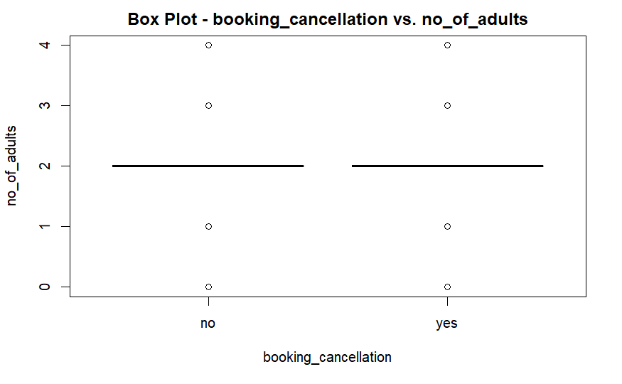

```
    Welch Two Sample t-test

data:  df[, v] by df[, target_var]
t = -6.0025, df = 20824, p-value = 1.975e-09
alternative hypothesis: true difference in means between group no and group yes is not equal to 0
95 percent confidence interval:
 -0.03764256 -0.01911039
sample estimates:
 mean in group no mean in group yes
       0.09598196        0.12435844

[1] "*************no_of_weekend_nights*************"
```

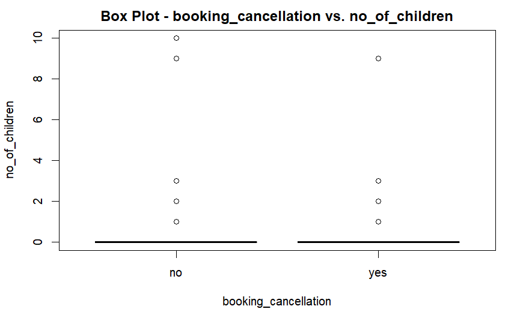

```
    Welch Two Sample t-test

data:  df[, v] by df[, target_var]
t = -11.404, df = 21843, p-value < 2.2e-16
alternative hypothesis: true difference in means between group no and group yes is not equal to 0
95 percent confidence interval:
 -0.13382358 -0.09456947
sample estimates:
 mean in group no mean in group yes
        0.7733087         0.8875053

[1] "*************no_of_week_nights*************"
```

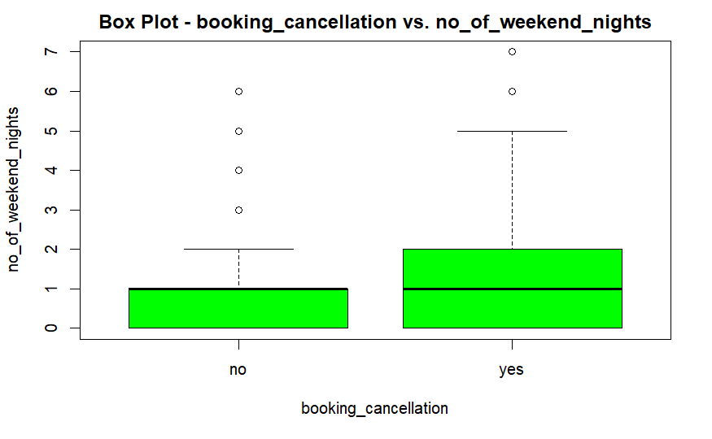

```
    Welch Two Sample t-test

data:  df[, v] by df[, target_var]
t = -16.672, df = 20040, p-value < 2.2e-16
alternative hypothesis: true difference in means between group no and group yes is not equal to 0
95 percent confidence interval:
 -0.3124142 -0.2466839
sample estimates:
 mean in group no mean in group yes
         2.112710          2.392259

[1] "*************required_car_parking_space*************"
```

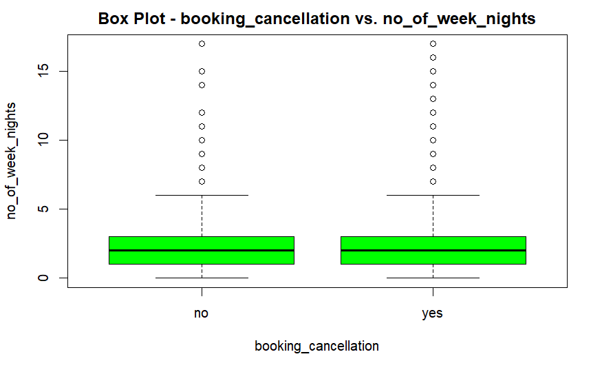

```
    Welch Two Sample t-test

data:  df[, v] by df[, target_var]
t = 20.424, df = 36272, p-value < 2.2e-16
alternative hypothesis: true difference in means between group no and group yes is not equal to 0
95 percent confidence interval:
 0.02876500 0.03487198
sample estimates:
 mean in group no mean in group yes
      0.041410414       0.009591923

[1] "*************lead_time*************"
```

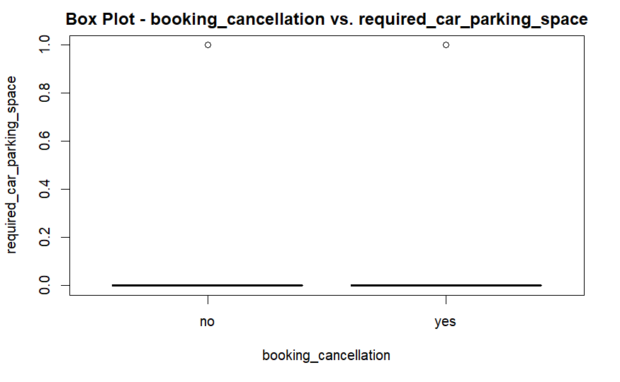

```
    Welch Two Sample t-test

data:  df[, v] by df[, target_var]
t = -80.617, df = 16886, p-value < 2.2e-16
alternative hypothesis: true difference in means between group no and group yes is not equal to 0
95 percent confidence interval:
 -82.24038 -78.33614
sample estimates:
 mean in group no mean in group yes
         58.92722         139.21548

[1] "*************arrival_year*************"
```

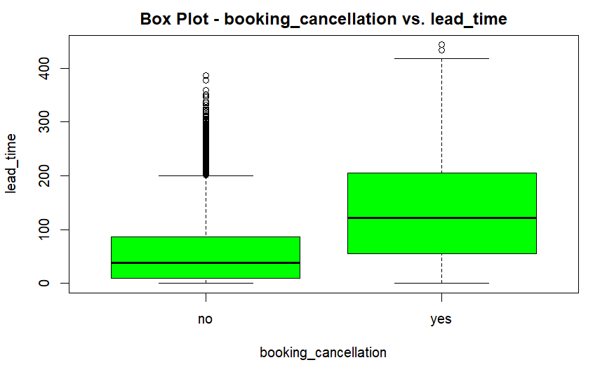

```
    Welch Two Sample t-test

data:  df[, v] by df[, target_var]
t = -40.013, df = 33430, p-value < 2.2e-16
alternative hypothesis: true difference in means between group no and group yes is not equal to 0
95 percent confidence interval:
 -0.1540090 -0.1396251
sample estimates:
 mean in group no mean in group yes
         2017.772          2017.919

[1] "*************arrival_month*************"
```

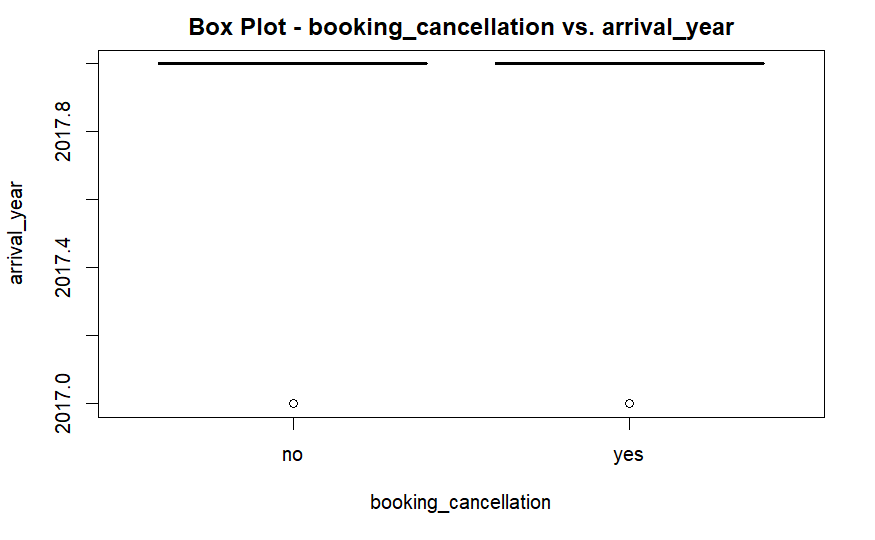

```
    Welch Two Sample t-test

data:  df[, v] by df[, target_var]
t = 2.2926, df = 28254, p-value = 0.02188
alternative hypothesis: true difference in means between group no and group yes is not equal to 0
95 percent confidence interval:
 0.01065661 0.13628582
sample estimates:
 mean in group no mean in group yes
         7.447724          7.374253

[1] "*************arrival_date*************"
```

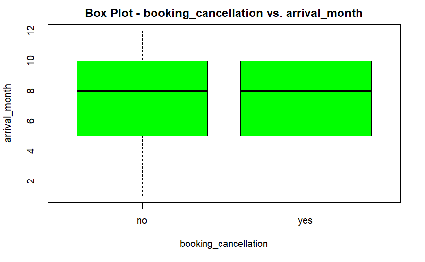

```
    Welch Two Sample t-test

data:  df[, v] by df[, target_var]
t = -2.0193, df = 23405, p-value = 0.04347
alternative hypothesis: true difference in means between group no and group yes is not equal to 0
95 percent confidence interval:
 -0.390068413 -0.005802809
sample estimates:
 mean in group no mean in group yes
         15.53214          15.73008

[1] "*************repeated_guest*************"
```

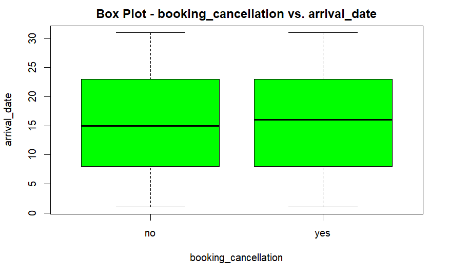

```
    Welch Two Sample t-test

data:  df[, v] by df[, target_var]
t = 28.633, df = 27928, p-value < 2.2e-16
alternative hypothesis: true difference in means between group no and group yes is not equal to 0
95 percent confidence interval:
 0.03365500 0.03860128
sample estimates:
 mean in group no mean in group yes
      0.037474375       0.001346235

[1] "*************no_of_previous_cancellations*************"
```

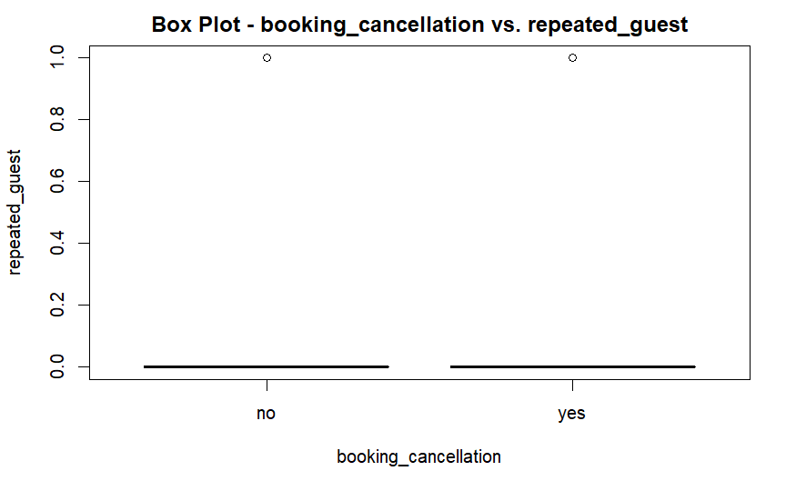

```
    Welch Two Sample t-test

data:  df[, v] by df[, target_var]
t = 7.6345, df = 35195, p-value = 2.324e-14
alternative hypothesis: true difference in means between group no and group yes is not equal to 0
95 percent confidence interval:
 0.01967287 0.03326333
sample estimates:
 mean in group no mean in group yes
      0.032021320       0.005553218

[1] "*************no_of_previous_bookings_not_canceled*************"
```

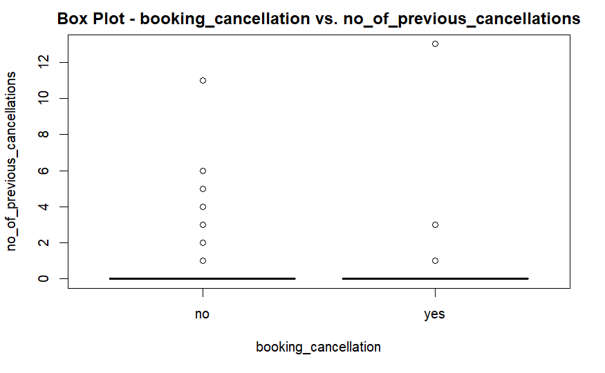

```
    Welch Two Sample t-test

data:  df[, v] by df[, target_var]
t = 16.402, df = 24757, p-value < 2.2e-16
alternative hypothesis: true difference in means between group no and group yes is not equal to 0
95 percent confidence interval:
 0.1980356 0.2517917
sample estimates:
 mean in group no mean in group yes
      0.227101271       0.002187631

[1] "*************avg_price_per_room*************"
```

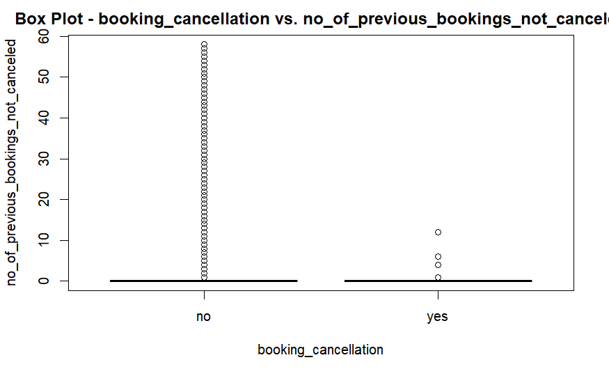

```
    Welch Two Sample t-test

data:  df[, v] by df[, target_var]
t = -28.451, df = 25929, p-value < 2.2e-16
alternative hypothesis: true difference in means between group no and group yes is not equal to 0
95 percent confidence interval:
 -11.392852  -9.924257
sample estimates:
 mean in group no mean in group yes
         99.93141         110.58997

[1] "*************no_of_special_requests*************"
```

[2 more figures not shown]

```r
# Checking the association of variables with target variable

assoc_num_df <- association_numerical_categorical(df = hotel_reservation_data,
                                                  numer_vars = categorized_features$numeric_cols,
                                                  target_var = target_DV)
```

```
[1] "-------------------- type_of_meal_plan --------------------"
```

```
    Pearson's Chi-squared test

data:  ctable
X-squared = 278.29, df = 3, p-value < 2.2e-16
```

```
[1] "-------------------- room_type_reserved --------------------"
```

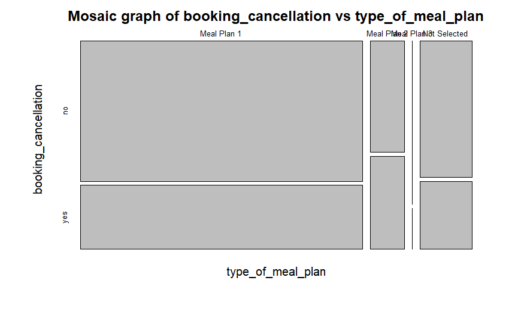

```
    Pearson's Chi-squared test

data:  ctable
X-squared = 57.335, df = 6, p-value = 1.563e-10
```

```
[1] "-------------------- market_segment_type --------------------"
```

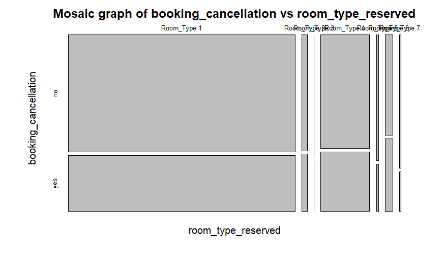

```
    Pearson's Chi-squared test

data:  ctable
X-squared = 814.11, df = 4, p-value < 2.2e-16
```

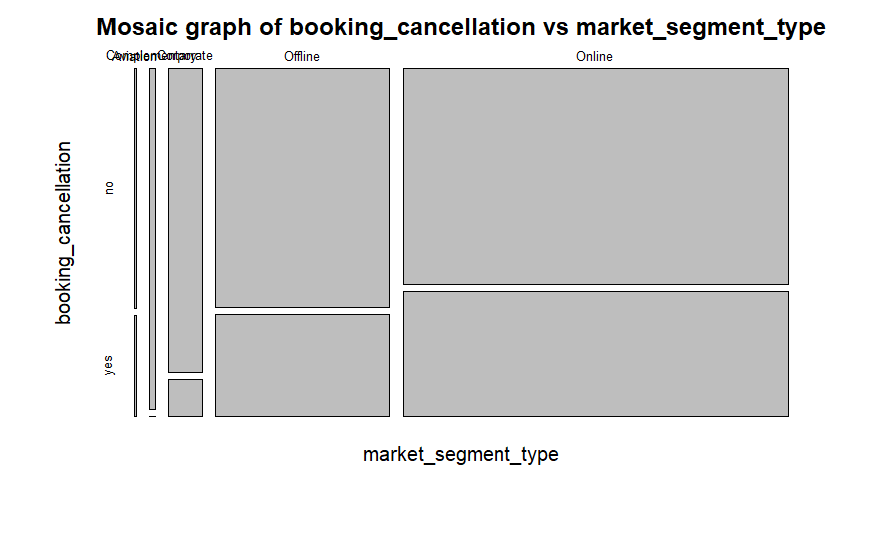

```r
assoc_fac_df <- association_categorical_categorical(df = hotel_reservation_data,
                                                    factor_vars = categorized_features$factor_cols,
                                                    target_var = target_DV)
```

```r
qualified_features_data <- assoc_num_df %>% rbind.data.frame(assoc_fac_df)

# CHATGPT: how to sort a dataframe in R?
qualified_features_data[order(qualified_features_data$result, decreasing = FALSE), ]
```

|  | feature1 | feature2 | p.value | signif | result |
| --- | --- | --- | --- | --- | --- |
| 1 | booking_cancellation | no_of_adults | 2.125196e-65 | 0.05 | pass |
| 2 | booking_cancellation | no_of_children | 1.974602e-09 | 0.05 | pass |
| 3 | booking_cancellation | no_of_weekend_nights | 4.838631e-30 | 0.05 | pass |
| 4 | booking_cancellation | no_of_week_nights | 5.450111e-62 | 0.05 | pass |
| 5 | booking_cancellation | required_car_parking_space | 3.368068e-92 | 0.05 | pass |
| 6 | booking_cancellation | lead_time | 0.000000e+00 | 0.05 | pass |
| 7 | booking_cancellation | arrival_year | 0.000000e+00 | 0.05 | pass |
| 8 | booking_cancellation | arrival_month | 2.187987e-02 | 0.05 | pass |
| 9 | booking_cancellation | arrival_date | 4.347123e-02 | 0.05 | pass |
| 10 | booking_cancellation | repeated_guest | 9.739645e-178 | 0.05 | pass |

[output cut: 7 more lines]

#### Let us get started with the modeling

```r
# Let us check the class blance
prop.table(table(hotel_reservation_data$booking_cancellation))
```

```
       no       yes
0.6723639 0.3276361
```

```r
# Let us bacup saiing a data
hotel_reservation_data_processed_bkup <- hotel_reservation_data
```

```r
# Let us split the data into train and test
# We are using 90% train and 10% test
# We have over 30K reords
train_index <- createDataPartition(y = hotel_reservation_data$booking_cancellation, p = 0.9, list = FALSE)
hotel_reservation_data_train <- hotel_reservation_data[train_index, ]
hotel_reservation_data_test <- hotel_reservation_data[-train_index, ]
```

```r
# Let us determiine the class weights
class_weights_values <- class_weight_determination_fn(output_var = hotel_reservation_data_train$booking_cancellation)
class_weights_vector <- ifelse(hotel_reservation_data_train$booking_cancellation == "yes",
                               class_weights_values$weight_yes, class_weights_values$weight_no)
```

#### Before deep dive into sophisticated modeling techniques, let us perform some simple heuristic calculation (AKA: Heuristic Model) to understand the data

Why did we select this variable? Usually reservation is cancelled only if booked. (Your reaction : Obviously) There are several variables in that can affect the cancellation but from a receptionist / owner point of view if there is cancellation after several days it gets really frustrating. Hence this is feature to concentrate.

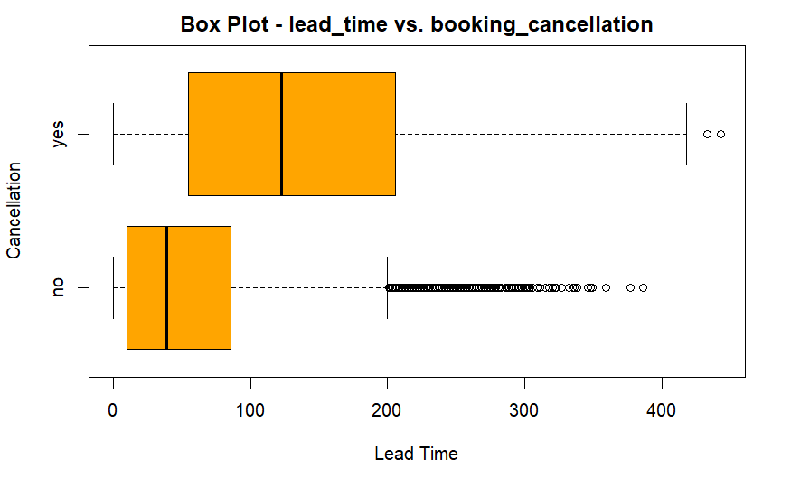

```r
# To understand the possibility of the reservation getting cancelled
# We have to understand the nummber of days between the date of booking and the arrival date
plot(hotel_reservation_data_train$lead_time ~ hotel_reservation_data_train$booking_cancellation,
     col="orange",
     main = paste("Box Plot - lead_time vs. booking_cancellation", sep = ""),
     xlab = "Cancellation",
     ylab = "Lead Time",
     horizontal = TRUE)
```

```r
# For "yes" category
summary_chk = summary(hotel_reservation_data_train[hotel_reservation_data_train$booking_cancellation == "yes", "lead_time"])
```

From the above graph we can understand that the if the lead time crosses 100 days, then there is huge possibility of the room reservation getting cancelled. Hence, we are going to use the median value to classfy the value.

Let us create becnh mark model by assessing the train data

```r
hotel_reservation_data
```

| no_of_adults | no_of_children | no_of_weekend_nights | no_of_week_nights | type_of_meal_plan | required_car_parking_space | room_type_reserved | lead_time | arrival_year | arrival_month | arrival_date | market_segment_type | repeated_guest | no_of_previous_cancellations | no_of_previous_bookings_not_canceled | avg_price_per_room | no_of_special_requests | booking_cancellation |
| --- | --- | --- | --- | --- | --- | --- | --- | --- | --- | --- | --- | --- | --- | --- | --- | --- | --- |
| 2 | 0 | 1 | 2 | Meal Plan 1 | 0 | Room_Type 1 | 224 | 2017 | 10 | 2 | Offline | 0 | 0 | 0 | 65.00 | 0 | no |
| 2 | 0 | 2 | 3 | Not Selected | 0 | Room_Type 1 | 5 | 2018 | 11 | 6 | Online | 0 | 0 | 0 | 106.68 | 1 | no |
| 1 | 0 | 2 | 1 | Meal Plan 1 | 0 | Room_Type 1 | 1 | 2018 | 2 | 28 | Online | 0 | 0 | 0 | 60.00 | 0 | yes |
| 2 | 0 | 0 | 2 | Meal Plan 1 | 0 | Room_Type 1 | 211 | 2018 | 5 | 20 | Online | 0 | 0 | 0 | 100.00 | 0 | yes |
| 2 | 0 | 1 | 1 | Not Selected | 0 | Room_Type 1 | 48 | 2018 | 4 | 11 | Online | 0 | 0 | 0 | 94.50 | 0 | yes |
| 2 | 0 | 0 | 2 | Meal Plan 2 | 0 | Room_Type 1 | 346 | 2018 | 9 | 13 | Online | 0 | 0 | 0 | 115.00 | 1 | yes |
| 2 | 0 | 1 | 3 | Meal Plan 1 | 0 | Room_Type 1 | 34 | 2017 | 10 | 15 | Online | 0 | 0 | 0 | 107.55 | 1 | no |
| 2 | 0 | 1 | 3 | Meal Plan 1 | 0 | Room_Type 4 | 83 | 2018 | 12 | 26 | Online | 0 | 0 | 0 | 105.61 | 1 | no |
| 3 | 0 | 0 | 4 | Meal Plan 1 | 0 | Room_Type 1 | 121 | 2018 | 7 | 6 | Offline | 0 | 0 | 0 | 96.90 | 1 | no |
| 2 | 0 | 0 | 5 | Meal Plan 1 | 0 | Room_Type 4 | 44 | 2018 | 10 | 18 | Online | 0 | 0 | 0 | 133.44 | 3 | no |

[output cut: 990 more lines]

```r
# Let us create separate train and test data for bench marking model
hotel_reservation_data_train_BENCHMARK <- hotel_reservation_data_train
hotel_reservation_data_test_BENCHMARK <- hotel_reservation_data_test

# Let us create a separate risk factor varaible
# to assess the percentage of people that have true in recidivism within 3 yers
# chat gpt: used chat gpt to get a one line code

# Let us merge the benchmark model summary with teh test data
hotel_reservation_data_test_BENCHMARK <- hotel_reservation_data_test_BENCHMARK %>%  mutate(
  prediction = ifelse(hotel_reservation_data_test_BENCHMARK$lead_time >= summary_chk[["Median"]], "yes", "no"))
hotel_reservation_data_test_BENCHMARK$prediction <- factor(hotel_reservation_data_test_BENCHMARK$prediction)
```

```r
conf_mat
```

```
Confusion Matrix and Statistics

          Reference
Prediction   no  yes
       no  2112  615
       yes  327  573

               Accuracy : 0.7403
                 95% CI : (0.7257, 0.7545)
    No Information Rate : 0.6725
    P-Value [Acc > NIR] : < 2.2e-16

                  Kappa : 0.3713

 Mcnemar's Test P-Value : < 2.2e-16

            Sensitivity : 0.4823
            Specificity : 0.8659
         Pos Pred Value : 0.6367
         Neg Pred Value : 0.7745
              Precision : 0.6367
                 Recall : 0.4823
                     F1 : 0.5489
             Prevalence : 0.3275
         Detection Rate : 0.1580
   Detection Prevalence : 0.2481
      Balanced Accuracy : 0.6741

       'Positive' Class : yes
```

```r
TP = 3391
TN = 668
FP = 492
FN = 2656

precision <- TP / (TP + FP)

# Calculate Recall
recall <- TP / (TP + FN)

# Calculate F1 Score
F1_score <- 2 * precision * recall / (precision + recall)

# Print the results
cat("Precision:", precision, "\n")
cat("Recall:", recall, "\n")
cat("F1 Score:", F1_score, "\n")
```

# Modeling

```r
# Variable to contain the list of models
MODEL_LIST <- list()

# Control Variables
# MODEL_K_FOLDS <- 10
MODEL_K_FOLDS <- 5
MODEL_CONTROL_METHOD <- "cv"
# MODEL_TRAIN_METHOD <- "gbm"
MODEL_METRIC <- "ROC"
MODEL_TRAIN_DATA <- hotel_reservation_data_train
MODEL_TEST_DATA <- hotel_reservation_data_test
MODEL_DV_VAR <- "booking_cancellation"
##-------
ALPHA_VALUE = list(
  LASSO = 1,
  RIDGE = 0,
  ELASTIC = seq(0, 1, length = 10)
)
LAMBDA_GRID <- 10^seq(-3, 3, length = 100)
```

```r
set.seed(1)
  control_values <- trainControl(method = MODEL_CONTROL_METHOD,
                                 number = MODEL_K_FOLDS,
                                 classProbs = TRUE,
                                 summaryFunction = twoClassSummary,
                                 verboseIter = TRUE)
```

```r
# First model
if(over_write_models) {
  print("Running Model...")

  set.seed(1)
  # Automatice Tuning / Not included hyper parmater values
  grid_gbm <- expand.grid(
    n.trees = c(50, 100, 150, 200),
    shrinkage = c(0.01, 0.05, 0.1))
  GRADIENT_BOOST_MODEL <- train(booking_cancellation ~ .,
                                data = MODEL_TRAIN_DATA,
                                method = "gbm",
                                weights = class_weights_vector,
                                metric = MODEL_METRIC,
                                trControl = control_values,
                                tuneGrid = grid_gbm,
                                verbose = TRUE)
  print(GRADIENT_BOOST_MODEL)

  # Savig the model objects for future use
  MODEL_NAME <- "GRADIENT_BOOST_MODEL"; MODEL_LIST[[MODEL_NAME]] <- GRADIENT_BOOST_MODEL;
  saveRDS(MODEL_LIST[[MODEL_NAME]], file = paste(models_folder_path,"/", MODEL_NAME,"_MODEL.rds",sep = ""))
}
```

```r
if(over_write_models) {
  print("Running Model...")

  set.seed(1)


  grid_lasso <- expand.grid(alpha = ALPHA_VALUE$LASSO, lambda = LAMBDA_GRID)

  LASSO_MODEL <- train(booking_cancellation ~.,
                       data = MODEL_TRAIN_DATA,
                       method = "glmnet",
                       weights = class_weights_vector,
                       metric = MODEL_METRIC,
                       trControl = control_values,
                       tuneGrid = grid_lasso,
                       verboseIter = TRUE,
                       verbose = TRUE)

  # print(LASSO_MODEL)
  # print(coef(LASSO_MODEL$finalModel, LASSO_MODEL$bestTune$lambda))

  # Savig the model objects for future use
  MODEL_NAME <- "LASSO_MODEL"; MODEL_LIST[[MODEL_NAME]] <- LASSO_MODEL;
  saveRDS(MODEL_LIST[[MODEL_NAME]], file = paste(models_folder_path,"/", MODEL_NAME,"_MODEL.rds",sep = ""))
}
```

```r
# gbm_predictions_prob = predict(m_weighted_gbm, MODEL_TEST_DATA, type="prob")
# gbm_predictions = prediction(predictions = gbm_predictions_prob$yes, MODEL_TEST_DATA$booking_cancellation)
#
# performance(gbm_predictions, measure = "auc")@y.values
#
# gbm_predicted_labels = predict(m_weighted_gbm, MODEL_TEST_DATA)
# confusionMatrix(gbm_predicted_labels, MODEL_TEST_DATA$booking_cancellation, positive="yes", mode="everything")
```

```r
RANDOM_FOREST_MODEL <- train(  booking_cancellation ~.,
                               data = MODEL_TRAIN_DATA,
                               method = "rf",
                               weights = class_weights_vector,
                               metric = MODEL_METRIC,
                               trControl = control_values,
                               tuneGrid = grid_rf,
                               importance = TRUE,
                               verbose = TRUE)
RANDOM_FOREST_MODEL <- train(  booking_cancellation ~.,
                               data = MODEL_TRAIN_DATA,
                               method = "rf",
                               weights = class_weights_vector,
                               metric = MODEL_METRIC,
                               trControl = control_values,
                               tuneGrid = grid_rf,
                               importance = TRUE,
                               verbose = TRUE)
print(RANDOM_FOREST_MODEL)
```

```
Random Forest

32648 samples
   17 predictor
    2 classes: 'no', 'yes'

No pre-processing
Resampling: Cross-Validated (5 fold)
Summary of sample sizes: 26118, 26118, 26119, 26118, 26119
Resampling results:

  ROC        Sens       Spec
  0.8907518  0.9788165  0.5290239

Tuning parameter 'mtry' was held constant at a value of 2
```

[figure not shown]

```r
# Fourth Model
# Set seed - for reproducibility
set.seed(1)

# Define Train Control for SVM
train_control_SVM <- trainControl(method = MODEL_CONTROL_METHOD,
                              number = MODEL_K_FOLDS,
                              classProbs = TRUE,
                              summaryFunction = twoClassSummary,
                              preProc = c("center", "scale"),
                              verboseIter = TRUE)

# Set Up MOdel

grid_svm <- expand.grid(C = c(.5, 1, 3, 5))

SVM_LINEAR_MODEL <- train( booking_cancellation ~.,
                           data = MODEL_TRAIN_DATA,
                           method = "svmLinear",
                           weights = class_weights_vector,
                           metric = MODEL_METRIC,
                           trControl = train_control_SVM,
                           tuneGrid = grid_svm,
                           verboseIter = TRUE,
                           verbose = TRUE)

# print(SVM_LINEAR_MODEL)
```

```r
control_values
```

```
$method
[1] "cv"

$number
[1] 5

$repeats
[1] NA

$search
[1] "grid"

$p
[1] 0.75

$initialWindow
NULL

$horizon
[1] 1

$fixedWindow
[1] TRUE

$skip
[1] 0

$verboseIter
[1] TRUE

$returnData
[1] TRUE

$returnResamp
[1] "final"

$savePredictions
[1] FALSE

$classProbs
```

[output cut: 73 more lines]

```
$adaptive$alpha
[1] 0.05

$adaptive$method
[1] "gls"

$adaptive$complete
[1] TRUE


$trim
[1] FALSE

$allowParallel
[1] TRUE
```

#### Let us construct the NN for this model

```r
# Let us first perfrorm necessary transformation
# Let us first row bind both the train and test dataframe and do one hot encoding
# This

hotel_reservation_data_train_bkup <- hotel_reservation_data_train
hotel_reservation_data_train_bkup$training_sample <- 1

hotel_reservation_data_test_bkup <- hotel_reservation_data_test
hotel_reservation_data_test_bkup$training_sample <- 0

# Concategnate the dataframes
hotel_reservation_data_combined_1 <- hotel_reservation_data_train_bkup %>% bind_rows(hotel_reservation_data_test_bkup)
rm(hotel_reservation_data_train_bkup, hotel_reservation_data_test_bkup)

# let usf first check the columns for one hot encoding
columns_for_one_hot_encoding <- categorize_features(hotel_reservation_data_combined_1)$factor_cols
columns_for_one_hot_encoding <- setdiff(columns_for_one_hot_encoding, MODEL_DV_VAR)

# Calling custom made one hot One HOt Enccoding
hotel_reservation_data_combined_2 <- one_hot_encoding_fn(data_val = hotel_reservation_data_combined_1,
                                                         features_to_encode = columns_for_one_hot_encoding)

# Transforming the outcome variable
# Take care of this variable toawrds the end, when you are predicting the outcom based on the model
hotel_reservation_data_combined_2$booking_cancellation <- (
  as.numeric(hotel_reservation_data_combined_2$booking_cancellation) - 1)

# hotel_reservation_data_combined_2[[MODEL_DV_VAR]] <- ifelse(
#   hotel_reservation_data_combined_2[[MODEL_DV_VAR]] == "yes", TRUE,
#   ifelse(hotel_reservation_data_combined_2[[MODEL_DV_VAR]] == "no", FALSE,
#          hotel_reservation_data_combined_2[[MODEL_DV_VAR]]))


str(hotel_reservation_data_combined_2)
```

```r
# Let us now break the newly updated data into train, test and train into train and validation
hotel_reservation_data_NN_train <- (hotel_reservation_data_combined_2 %>%
                                      filter(training_sample == 1) %>%
                                      select(-all_of("training_sample")))
hotel_reservation_data_NN_test <- (hotel_reservation_data_combined_2 %>%
                                     filter(training_sample == 0) %>%
                                     select(-all_of("training_sample")))

# Removing this column from the combined datasets
hotel_reservation_data_combined_3 <- hotel_reservation_data_combined_1
hotel_reservation_data_combined_2 <- hotel_reservation_data_combined_2 %>% select(-all_of("training_sample"))
hotel_reservation_data_combined_1 <- hotel_reservation_data_combined_1 %>% select(-all_of("training_sample"))
```

```r
# Let us split the train data to train and validation data set
inTrainVal = createDataPartition(hotel_reservation_data_NN_train$booking_cancellation, p=0.9, list=FALSE)
hotel_reservation_data_NN_train_val   = hotel_reservation_data_NN_train[-inTrainVal,]
hotel_reservation_data_NN_train_train = hotel_reservation_data_NN_train[inTrainVal,]
```

```r
# Let us scale the numerical variables
numerical_cols_to_scale <- categorize_features(hotel_reservation_data_combined_1)$numeric_cols
# hotel_reservation_data_combined_1[, numerical_cols_to_scale]

data_train = hotel_reservation_data_NN_train_train
data_val = hotel_reservation_data_NN_train_val
data_test = hotel_reservation_data_NN_test

numerical_features = numerical_cols_to_scale

# Scaling the features
data_train <- data_train %>%  mutate_at(vars(numerical_features), as.numeric)

# Reusig code form the lectures
scaled_data_train <- scale(data_train[, numerical_features])

col_means_train <- attr(scaled_data_train, "scaled:center")
col_stddevs_train <- attr(scaled_data_train, "scaled:scale")

scaled_data_test <- scale(data_test[, numerical_features], center = col_means_train, scale = col_stddevs_train)

scaled_data_val <- scale(data_val[, numerical_features], center = col_means_train, scale = col_stddevs_train)

# Re arragning the features in all the datasets
# Using the train scaling feauters to avoid data leakage
data_train <- cbind(scaled_data_train, data_train[, !(colnames(data_train) %in% numerical_features)])
data_test <- cbind(scaled_data_test, data_test[, !(colnames(data_test) %in% numerical_features)])
data_val <- cbind(scaled_data_val, data_val[, !(colnames(data_val) %in% numerical_features)])

# Returing the data
# Will construct this into a function in fututre project
hotel_reservation_data_NN_train_train = data_train
hotel_reservation_data_NN_train_val = data_val
hotel_reservation_data_NN_test = data_test
```

```r
# Dissecting the IDVs and DVs
train_IDV <- as.matrix(hotel_reservation_data_NN_train_train %>% select(-one_of(c(MODEL_DV_VAR))))
train_DV <- (hotel_reservation_data_NN_train_train[, MODEL_DV_VAR])

test_IDV <- as.matrix(hotel_reservation_data_NN_test %>% select(-one_of(c(MODEL_DV_VAR))))
test_DV <- as.matrix(hotel_reservation_data_NN_test[, MODEL_DV_VAR])

val_IDV <- as.matrix(hotel_reservation_data_NN_train_val %>% select(-one_of(c(MODEL_DV_VAR))))
val_DV <- hotel_reservation_data_NN_train_val[, MODEL_DV_VAR]
```

#### Let us create a simple model first and move on to construcutig tuned model

```r
set.seed(1)

# Simple Model
simple_model <- (
  keras_model_sequential() %>%
    layer_dense(units = 16, activation = "sigmoid", input_shape = dim(train_IDV)[2]) %>%
    layer_dropout(rate = 0.1) %>%
    layer_dense(units = 16, activation = "sigmoid") %>%
    layer_dropout(rate = 0.1) %>%
    layer_dense(units =  1, activation = "sigmoid")
)

simple_model %>% compile(optimizer = optimizer_adam(learning_rate = 0.01),
                         loss = 'binary_crossentropy',
                         metrics = c('accuracy'))

# Checkign the model structure
print(simple_model)

# Trainging the model
history <- simple_model %>% fit(
  x = train_IDV,
  y = train_DV,
  epochs = 10,
  batch_size = 16,
  validation_data = list(val_IDV, val_DV),
  class_weight = list("0" = class_weights_values$weight_no, "1" = class_weights_values$weight_yes),
  verbose = 1
)

history

plot(history)

# Prediction
predicted_labels <- as.numeric(simple_model %>% predict(test_IDV) %>% k_argmax())
cross_table <- table(Actual_Labels = test_DV, Predicted_Labels = predicted_labels)
print(cross_table)
```

```r
# Performing multiple TF runs
# Just using small values
# Running it on my local machine
tuning_path = "D:/UIS/Studies/Semester4/CSC532/Assignments/ML_Final_Project/ml_final_project/code_base/final_project_tuning.R"
# nodes_list = c(64, 128, 256, 392, 512, 1024)
nodes_list = c(8)
learning_rates_list = c(0.01, 0.05, 0.001)#, 0.005)
# batch_size_list = c(16, 32, 64, 128)
batch_size_list = c(8)
activations_list = c( "sigmoid")#,  "relu", "tanh")
sample_perc = 0.01

# Performing tUNED NN
runs <- tuning_run(tuning_path,
                   flags = list(
                     nodes = nodes_list,
                     learning_rate = learning_rates_list,
                     batch_size = batch_size_list,
                     activation = activations_list
                     ),
                   sample = sample_perc)
```

```r
# Extracting the TF run information
# Sorting based on the metric loss
runs <- runs[order(runs$metric_val_loss, decreasing = FALSE),]
as.data.frame(runs)
```

```r
# Let’s view the summary of the best run
view_run(runs$run_dir[1])
```

```r
# Saving runs for future use
# class(runs)
# MODEL_NAME <- "NEURAL_NETWORK"; MODEL_LIST[[MODEL_NAME]] <- LASSO_MODEL;
# saveRDS(MODEL_LIST[[MODEL_NAME]], file = paste(models_folder_path,"/", MODEL_NAME,"_MODEL.rds",sep = ""))
runs_save_file_name = paste("NN_RUNS_", format(Sys.time(), "%Y%m%d_%H%M"), ".csv", sep = "")
runs_save_file_name = paste(models_folder_path,"/", runs_save_file_name, sep = "")
write.csv(runs, file = runs_save_file_name, row.names = FALSE)
print(paste(runs_save_file_name, " - file saved"))
```

```r
# Let us conctaente the val and train datasets
all_train_x <- abind(train_IDV, val_IDV, along = 1)
all_train_y <- abind(train_DV, val_DV, along = 1)
str(all_train_x)
str(all_train_y)
```

Let us perform the final model (neural networks)

```r
# Tunedd Parameters Values
final_tuned_params <- list(
  "nodes" = 8,
  "batch_size" = 8,
  "activation" = "sigmoid",
  "learning_rate" = 0.01,
  "epochs" = 10
)
```

```r
# Final Neural Network model
final_model <- keras_model_sequential()

final_model %>%
  layer_dense(units = final_tuned_params$nodes, activation = final_tuned_params$activation, input_shape = dim(all_train_x)[2]) %>%
  layer_dropout(rate = 0.5) %>%
  layer_dense(units = final_tuned_params$nodes, activation = final_tuned_params$activation ) %>%
  layer_dropout(rate = 0.5) %>%
  layer_dense(units = final_tuned_params$nodes, activation = final_tuned_params$activation ) %>%
  layer_dropout(rate = 0.5) %>%
  layer_dense(units = 1, activation = final_tuned_params$activation)

final_model %>% compile(optimizer = optimizer_adam(learning_rate = final_tuned_params$learning_rate),
                        loss = 'binary_crossentropy',
                        metrics = c('accuracy'))

final_model_compile <- final_model %>% fit(x = all_train_x,
                                           y = all_train_y,
                                           batch_size = final_tuned_params$batch_size,
                                           epochs = final_tuned_params$epochs,
                                           class_weight = list("0" = class_weights_values$weight_no,
                                                               "1" = class_weights_values$weight_yes),
                                           verbose = 1)
```

```r
final_model %>% evaluate(test_IDV, test_DV)
```

```r
predicted_probs = final_model %>% predict(test_IDV)
ann_predictions = prediction(predicted_probs, test_DV)

performance(ann_predictions, measure = "auc")@y.values

predicted.labels= factor(ifelse(predicted_probs>0.5, "1", "0"))
confusionMatrix(predicted.labels, as.factor(test_DV), mode="everything", positive="1")
```

[output not shown]